# Group#2 Homework# 3 - Logistic Regression

Group 2

3/29/2018

# Introduction

Github was used to manage the project. Using Github helped with version control and ensured each team member had access to the latest version of the project documentation.

Slack was used to by the team to communicate during the project and for quick access to code and documentation.

# Dataset

For reproducibility of the results, the data was loaded to and accessed from a Github repository. The age variable was rounded to a whole number.

# Data Exploration

The following variables comprise the data set. The response variable (Target) is the variable of interest. The response variable is binary (0, 1) and identifies whether the crime rate is above the median crime rate. The remaining 12 variables are predictors. All variables are numeric.

| Variable Name | Definition | Variable Type | Data Type |
| --- | --- | --- | --- |
| zn | proportion of residential land zoned for large lots (over 25000 square feet) | Predictor | Count |
| indus | proportion of non-retail business acres per suburb | Predictor | Count |
| chas | a dummy var. for whether the suburb borders the Charles River (1) or not (0) | Predictor | Count |
| nox | nitrogen oxides concentration (parts per 10 million) | Predictor | Count |
| rm | average number of rooms per dwelling | Predictor | Count |
| age | proportion of owner-occupied units built prior to 1940 | Predictor | Count |
| dis | weighted mean of distances to five Boston employment centers | Predictor | Count |
| rad | index of accessibility to radial highways | Predictor | Count |
| tax | full-value property-tax rate per $10,000 | Predictor | Count |
| ptratio | pupil-teacher ratio by town | Predictor | Count |
| lstat | lower status of the population (percent) | Predictor | Count |
| medv | median value of owner-occupied homes in $1000s | Predictor | Count |
| traget | whether the crime rate is above the median crime rate (1) or not (0) | Response | Count |

Descriptive statistics were calculated to examine the basic features of the data.

```
##         vars   n   mean     sd median trimmed    mad    min    max  range
## zn         1 466  11.58  23.36   0.00    5.35   0.00   0.00 100.00 100.00
## indus      2 466  11.11   6.85   9.69   10.91   9.34   0.46  27.74  27.28
## chas       3 466   0.07   0.26   0.00    0.00   0.00   0.00   1.00   1.00
## nox        4 466   0.55   0.12   0.54    0.54   0.13   0.39   0.87   0.48
## rm         5 466   6.29   0.70   6.21    6.26   0.52   3.86   8.78   4.92
## age        6 466  68.35  28.32  77.00   70.93  29.65   3.00 100.00  97.00
## dis        7 466   3.80   2.11   3.19    3.54   1.91   1.13  12.13  11.00
## rad        8 466   9.53   8.69   5.00    8.70   1.48   1.00  24.00  23.00
## tax        9 466 409.50 167.90 334.50  401.51 104.52 187.00 711.00 524.00
## ptratio   10 466  18.40   2.20  18.90   18.60   1.93  12.60  22.00   9.40
## lstat     11 466  12.63   7.10  11.35   11.88   7.07   1.73  37.97  36.24
## medv      12 466  22.59   9.24  21.20   21.63   6.00   5.00  50.00  45.00
## target    13 466   0.49   0.50   0.00    0.49   0.00   0.00   1.00   1.00
##          skew kurtosis   se    IQR   Q0.1  Q0.25  Q0.75   Q0.9
## zn       2.18     3.81 1.08  16.25   0.00   0.00  16.25  45.00
## indus    0.29    -1.24 0.32  12.96   2.91   5.15  18.10  19.58
## chas     3.34     9.15 0.01   0.00   0.00   0.00   0.00   0.00
## nox      0.75    -0.04 0.01   0.18   0.43   0.45   0.62   0.71
## rm       0.48     1.54 0.03   0.74   5.57   5.89   6.63   7.17
## age     -0.58    -1.01 1.31  50.00  26.00  44.00  94.00  99.00
## dis      1.00     0.47 0.10   3.11   1.61   2.10   5.21   6.81
## rad      1.01    -0.86 0.40  20.00   3.00   4.00  24.00  24.00
## tax      0.66    -1.15 7.78 385.00 233.00 281.00 666.00 666.00
## ptratio -0.75    -0.40 0.10   3.30  14.70  16.90  20.20  20.90
## lstat    0.91     0.50 0.33   9.89   4.70   7.04  16.93  22.86
## medv     1.08     1.37 0.43   7.98  12.70  17.02  25.00  34.90
## target   0.03    -2.00 0.02   1.00   0.00   0.00   1.00   1.00
```

```
##   zn indus chas nox rm age dis rad tax ptratio lstat medv target
## 1  0     0    0   0  0   0   0   0   0       0     0    0      0
```

The following looks at all of the predictor variables compared to each other and the response, with red values showing observations where the crime rate exceeded the median.

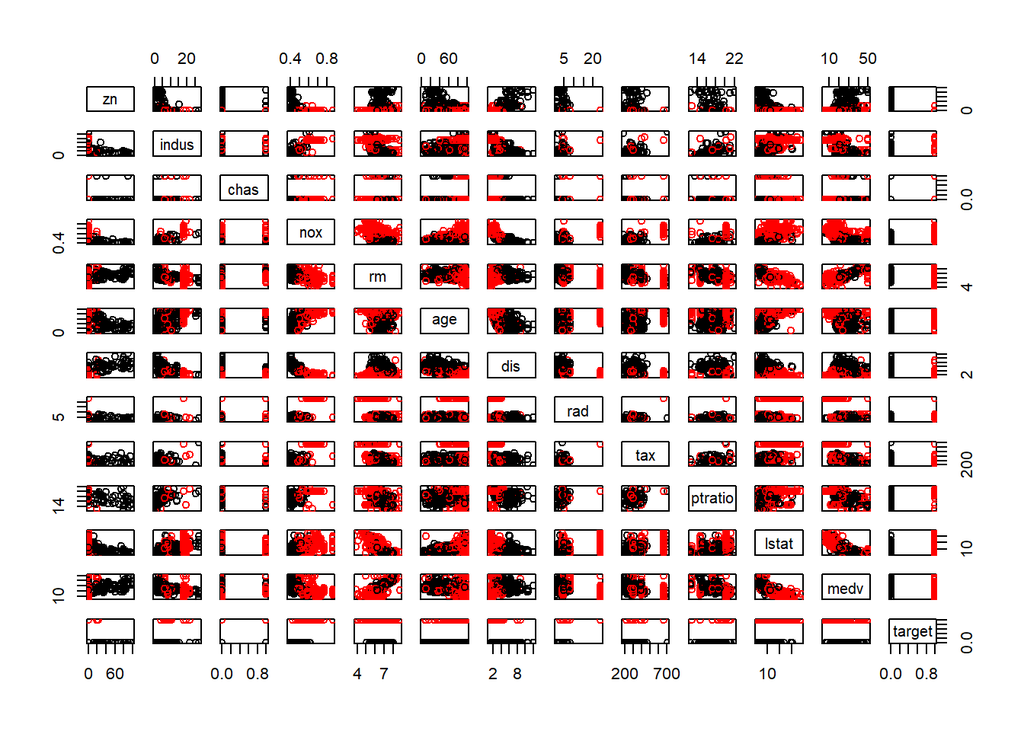

# zn

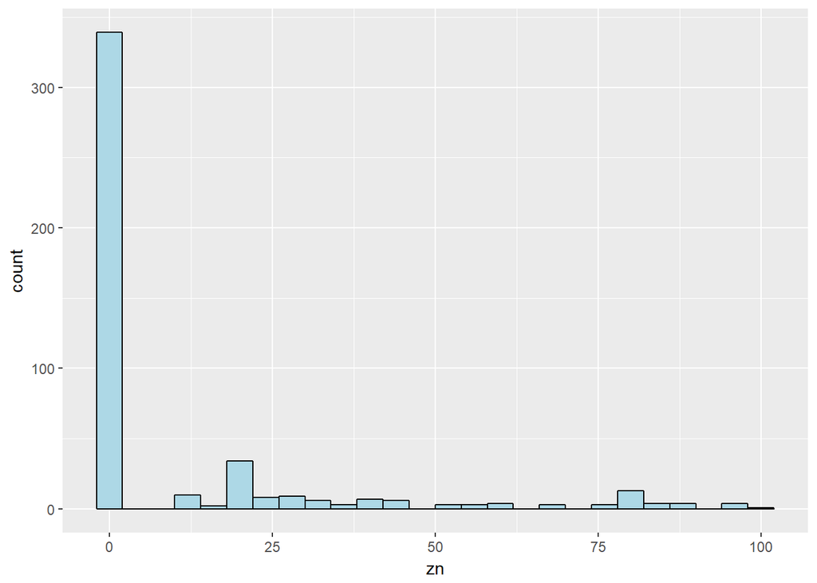

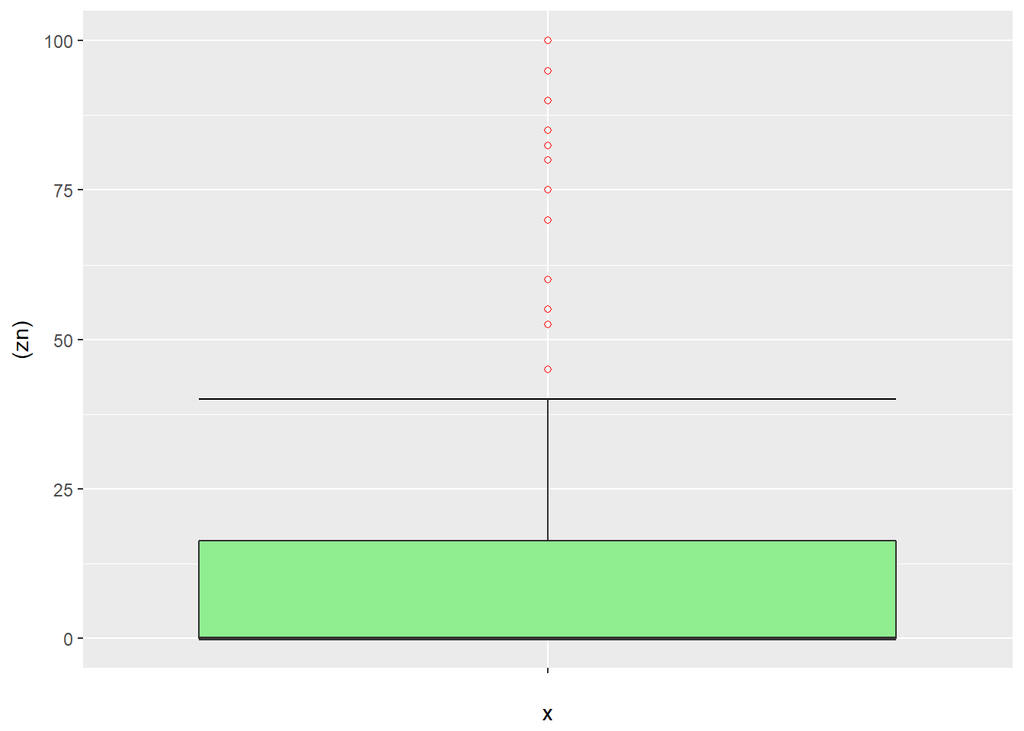

```
## $Obs
## [1] 100.0  95.0  90.0  85.0  82.5
##
## $Hi
## [1] 100  95
##
## $Low
## [1] 82.5 85.0
```

# indus

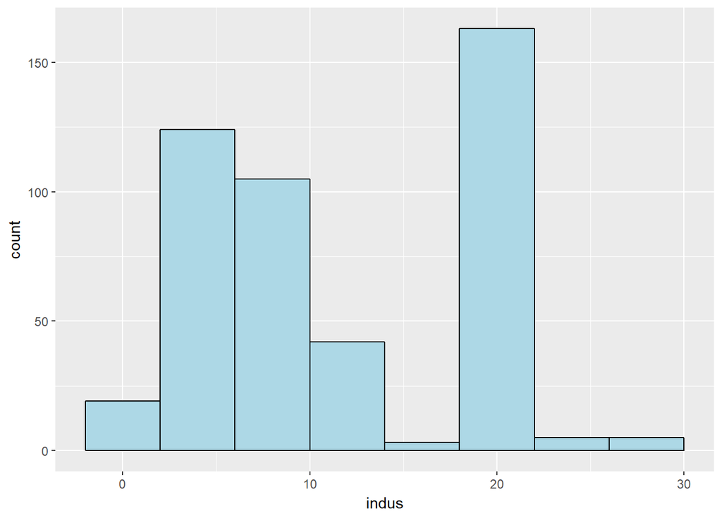

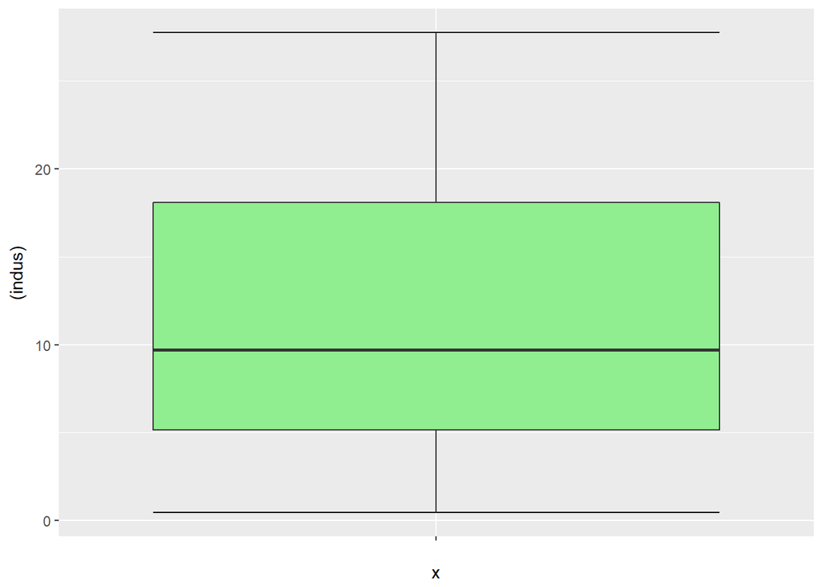

```
## $Obs
## numeric(0)
##
## $Hi
## [1] NA
##
## $Low
## numeric(0)
```

# nox

[figure not shown]

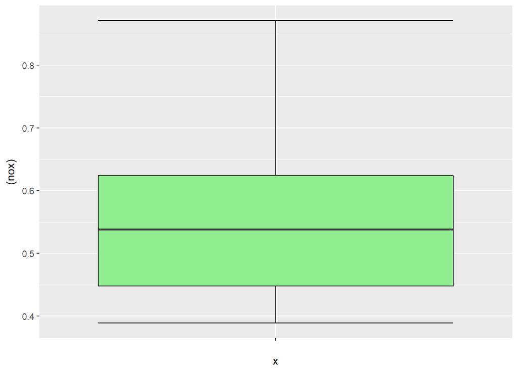

```
## $Obs
## numeric(0)
##
## $Hi
## [1] NA
##
## $Low
## numeric(0)
```

# rm

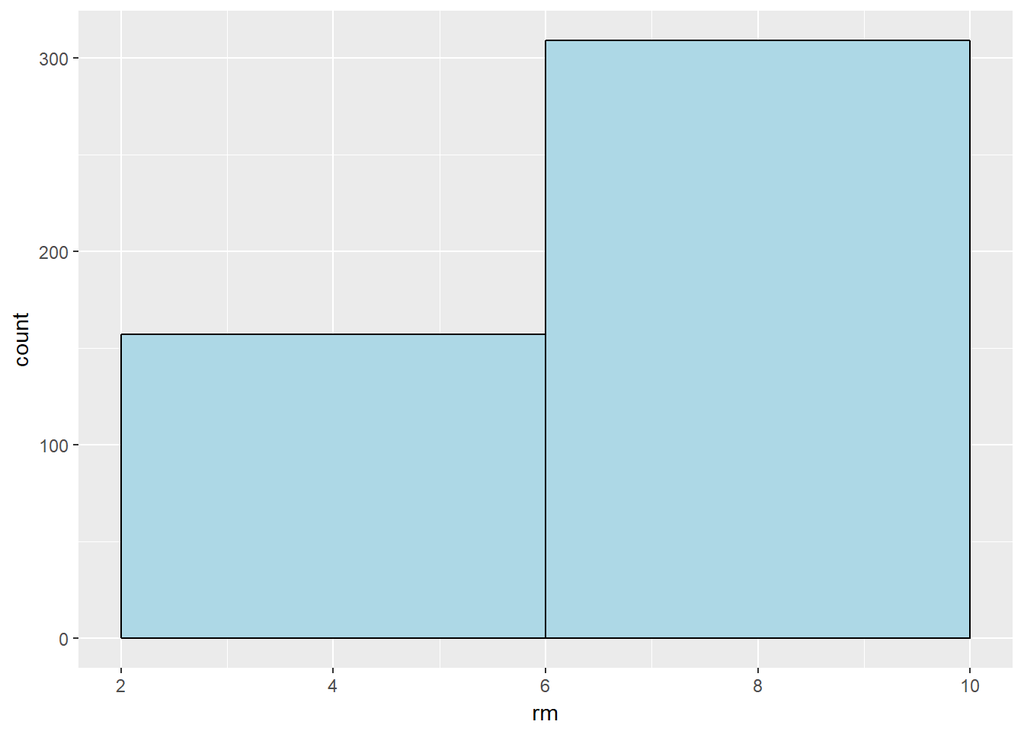

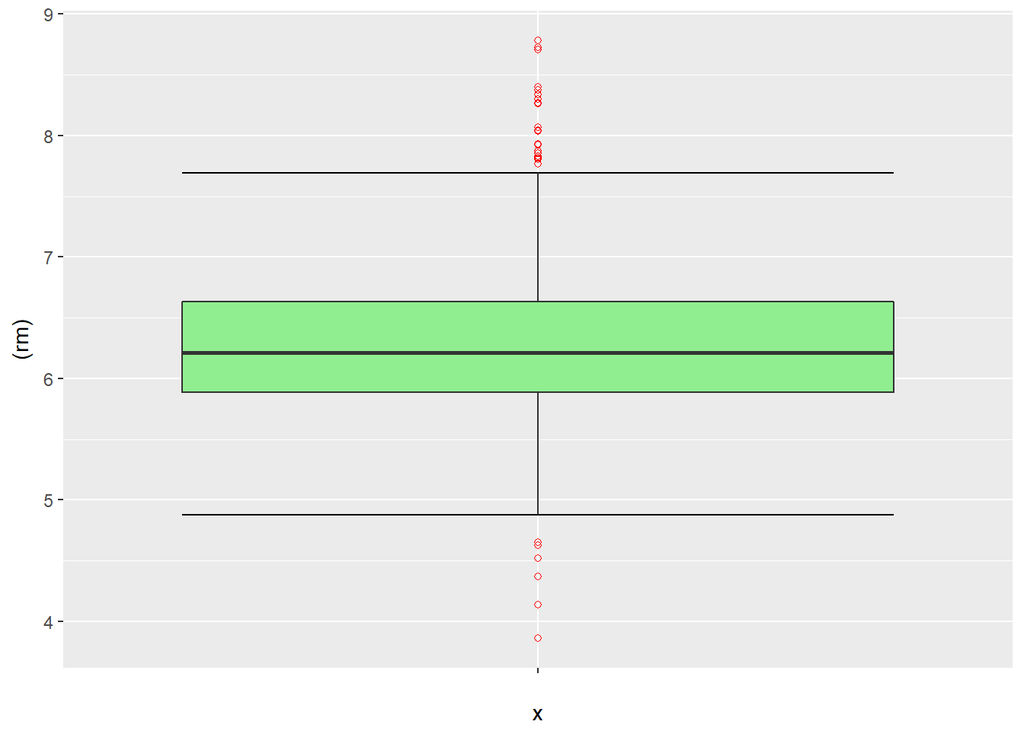

```
## $Obs
## [1] 8.780 8.725 8.704 4.138 3.863
##
## $Hi
## [1] 8.780 8.725
##
## $Low
## [1] 3.863 4.138
```

# age

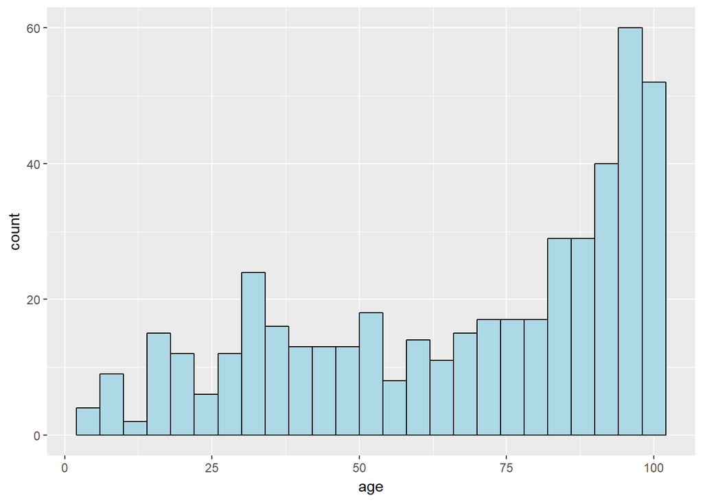

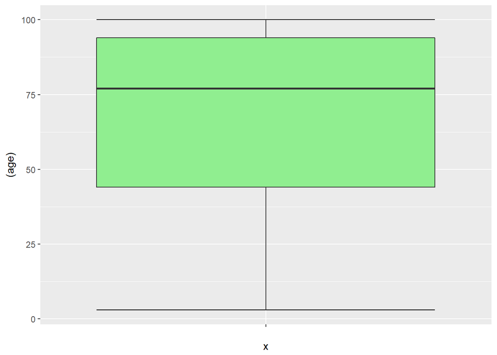

```
## $Obs
## numeric(0)
##
## $Hi
## [1] NA
##
## $Low
## numeric(0)
```

# dis

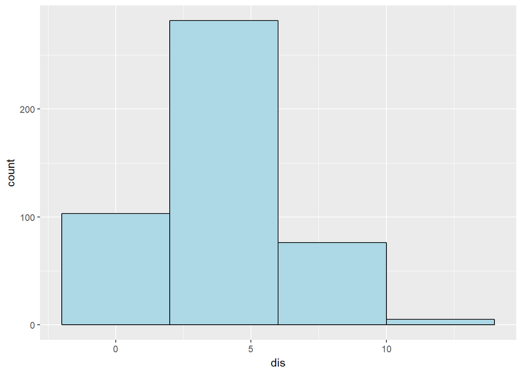

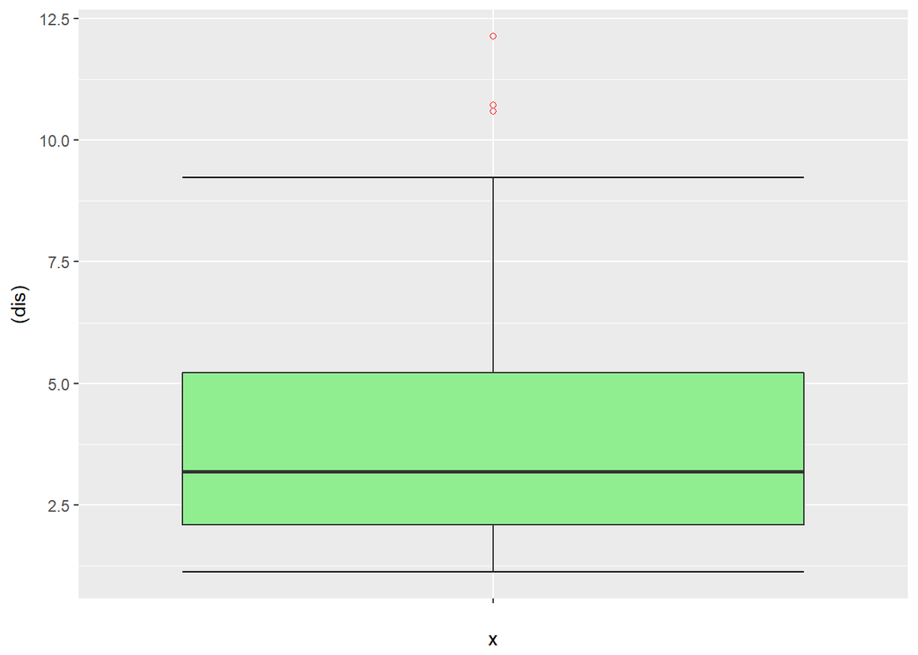

```
## $Obs
## [1] 12.1265 10.7103 10.5857
##
## $Hi
## [1] 12.1265
##
## $Low
## [1] 10.5857
```

# rad

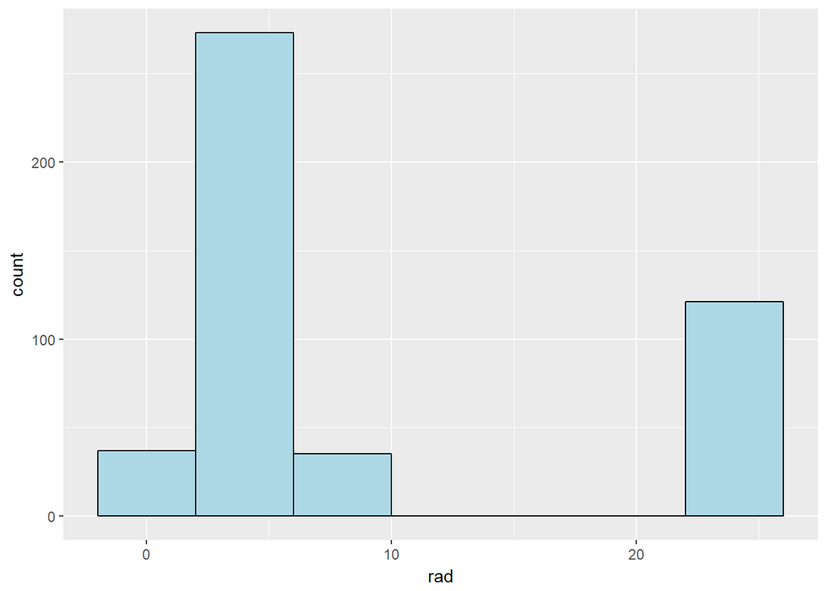

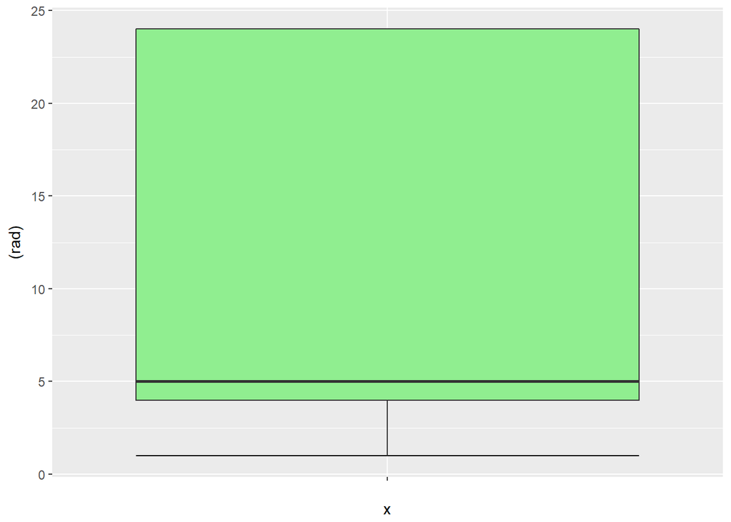

```
## $Obs
## integer(0)
##
## $Hi
## [1] NA
##
## $Low
## integer(0)
```

# tax

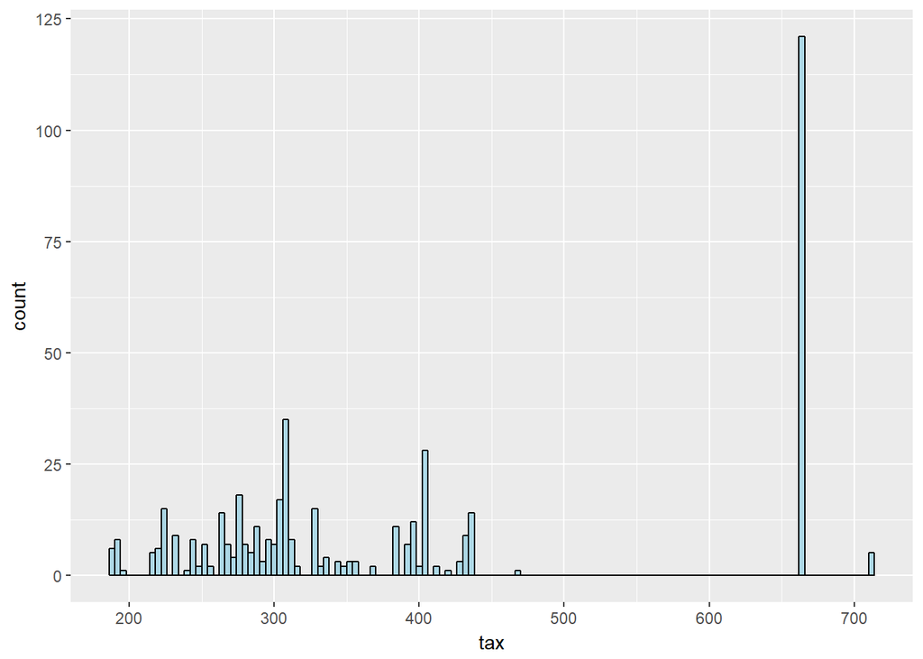

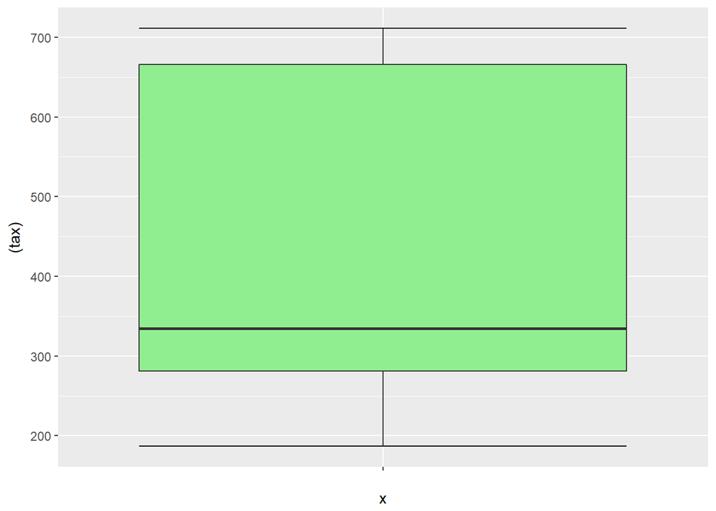

```
## $Obs
## integer(0)
##
## $Hi
## [1] NA
##
## $Low
## integer(0)
```

# ptratio

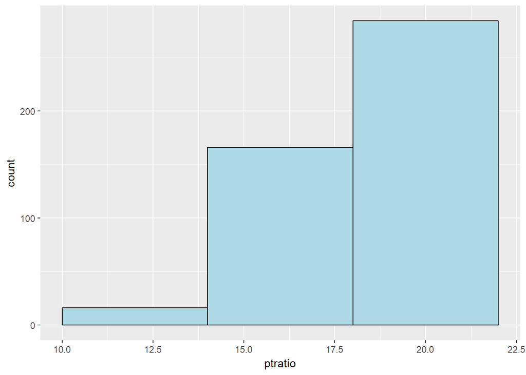

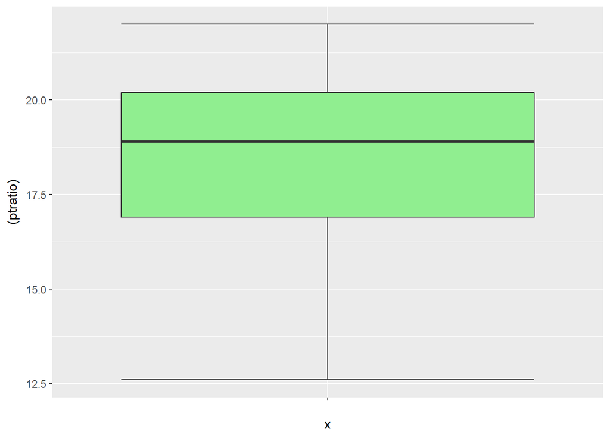

```
## $Obs
## numeric(0)
##
## $Hi
## [1] NA
##
## $Low
## numeric(0)
```

# lstat

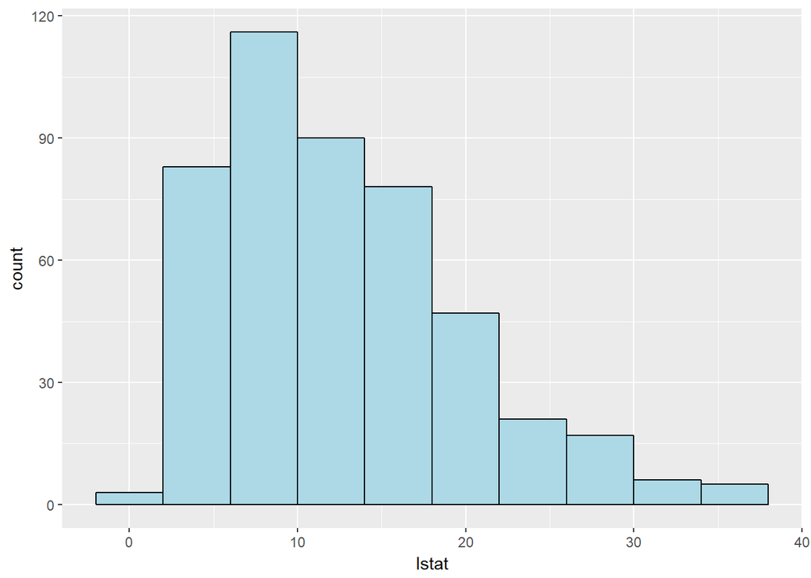

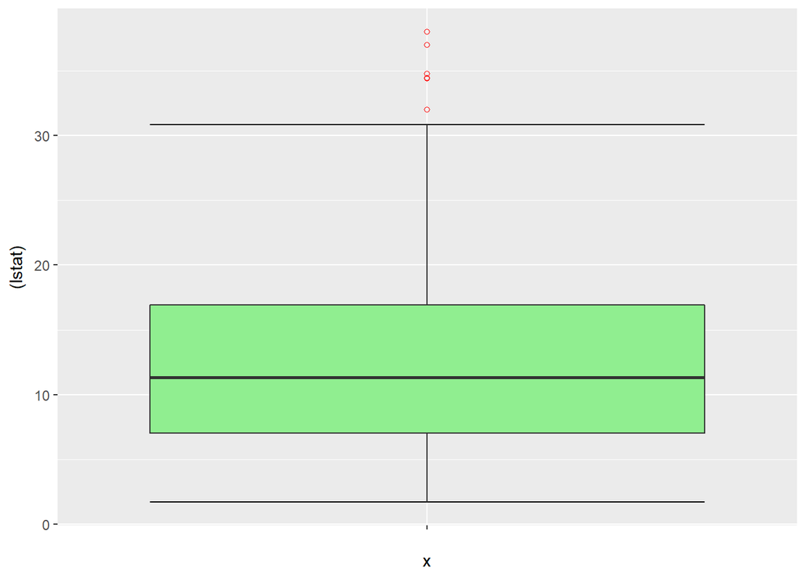

```
## $Obs
## [1] 37.97 36.98 34.77 34.41 34.37
##
## $Hi
## [1] 37.97 36.98
##
## $Low
## [1] 34.37 34.41
```

# medv

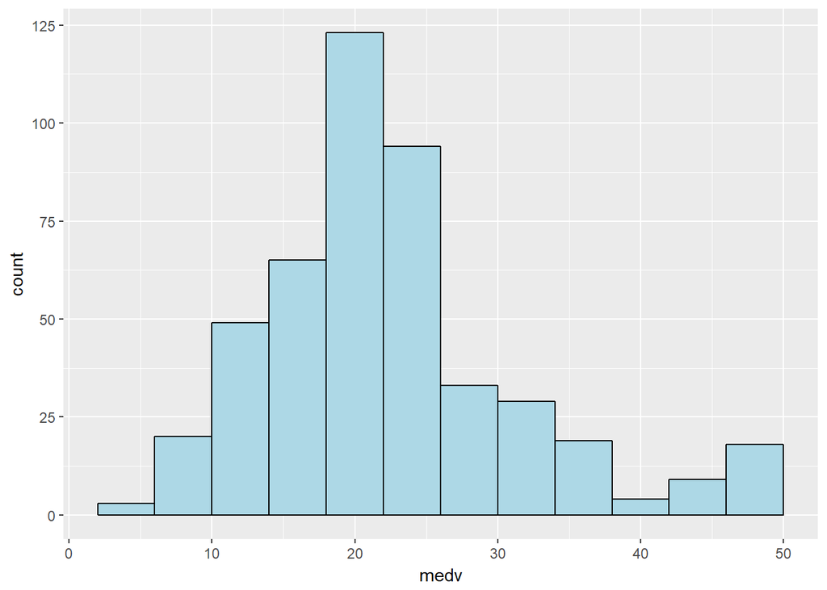

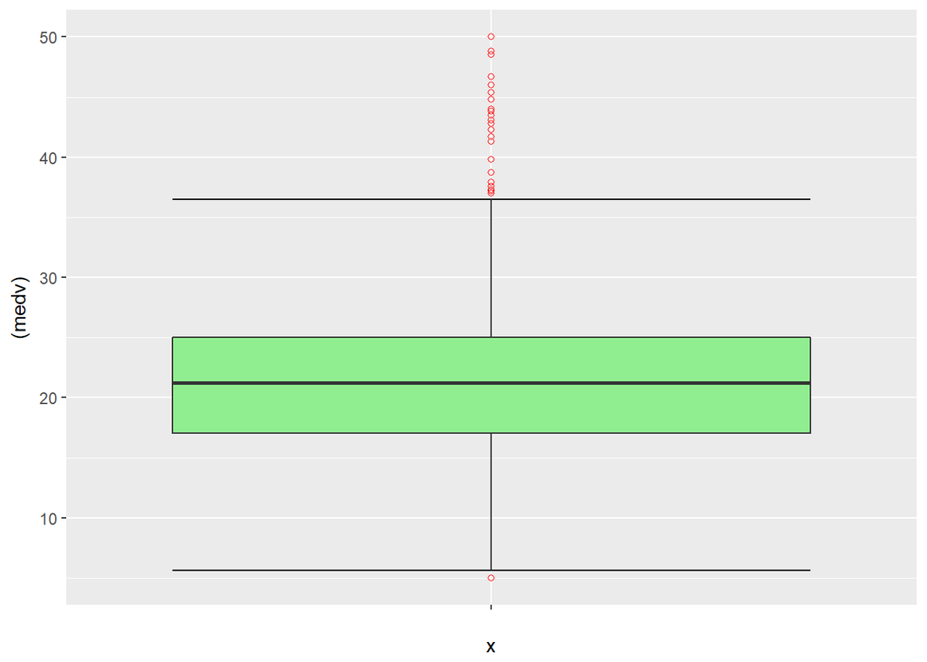

[output not shown]

# Correlation between variables

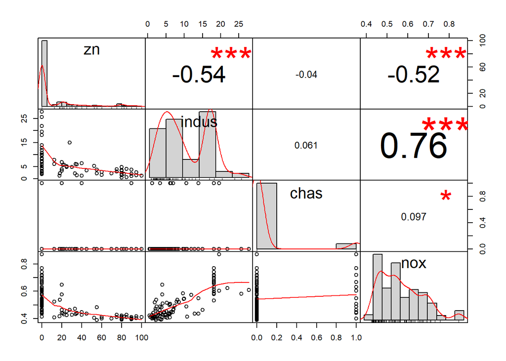

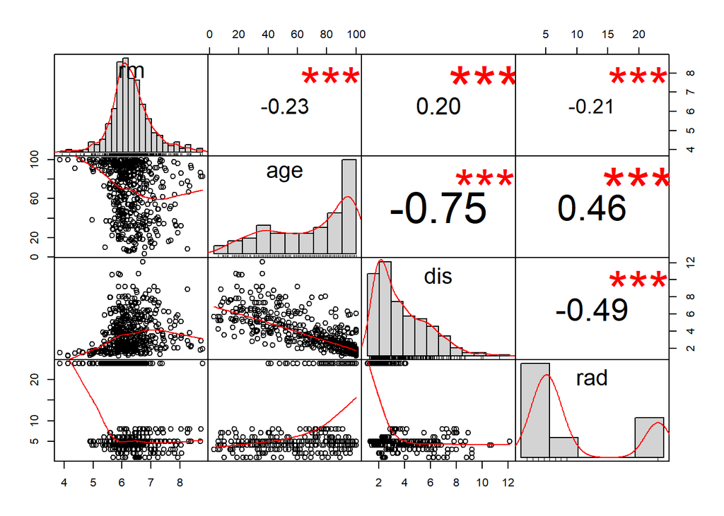

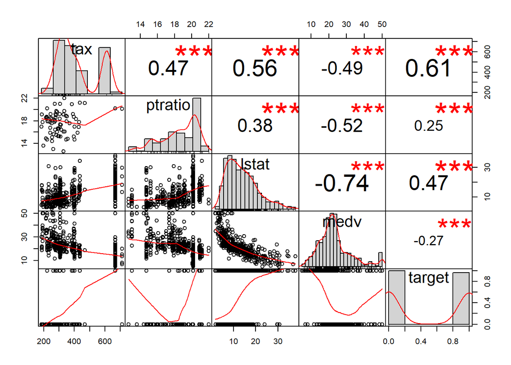

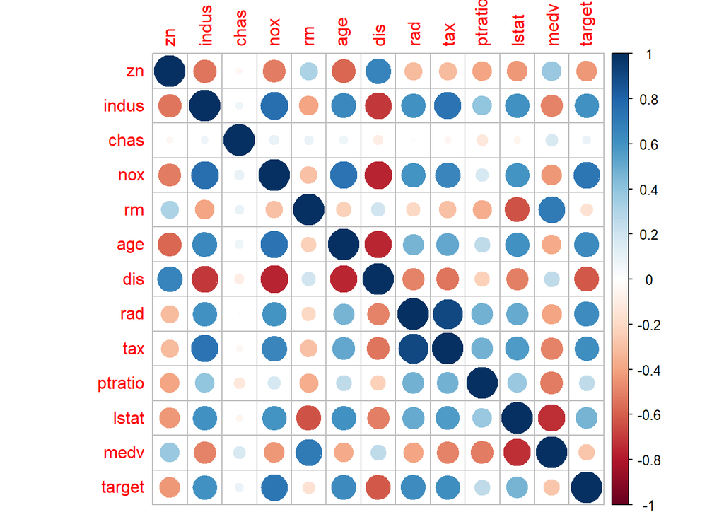

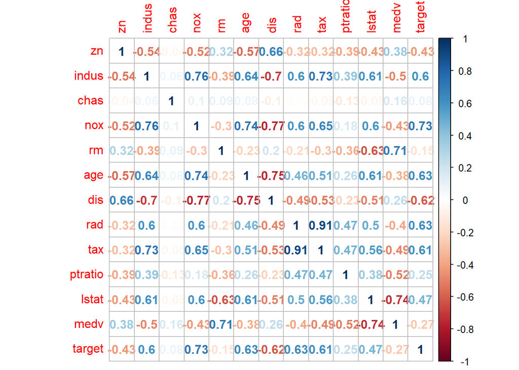

# Data Preparation

There are no NA values in the data; however, it is possible that zero values in a particular data set may be equivalent to missing information. For instance, we would not expect to see any observation where the average number of rooms per dwelling is equal to zero. We look at the dataset to determine if there are zero values for each variable and check for reasonableness.

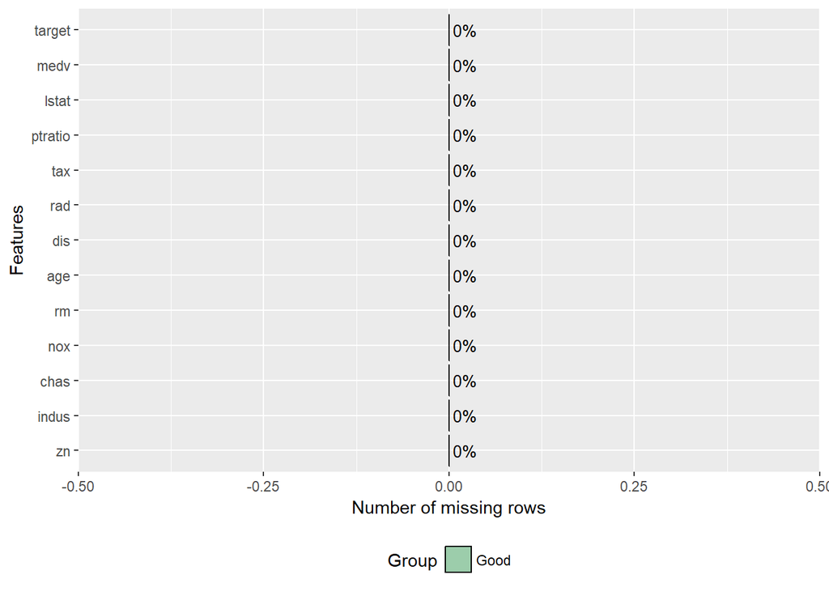

```r
plot_missing(crime_trainData)
```

```r
#Count of zero values
kable(colSums(crime_trainData==0))
```

|  | x |
| --- | --- |
| zn | 339 |
| indus | 0 |
| chas | 433 |
| nox | 0 |
| rm | 0 |
| age | 0 |
| dis | 0 |
| rad | 0 |
| tax | 0 |
| ptratio | 0 |
| lstat | 0 |
| medv | 0 |
| target | 237 |

It is reasonable that there could be no land zoned for large lots (zn) in a particular suburb. The chas variable is a binary variable that tells us whether a suburb borders the Charles river, with zero meaning no, and the target variable is also binary. It is also feasible that the other variables would not necessarilly contain zero values. It appears that this data set did not contain any missing values.

**Transformations**

In the case of logistic regression, transformations are not necessary as normality of predictors is not required. We can compare the independent variable itself to the dependent variable using marginal model plots to help us determine if transformation improves the fit between the predictor and response.

https://www.researchgate.net/post/Should_I_transform_non-normal_independent_variables_in_logistic_regression

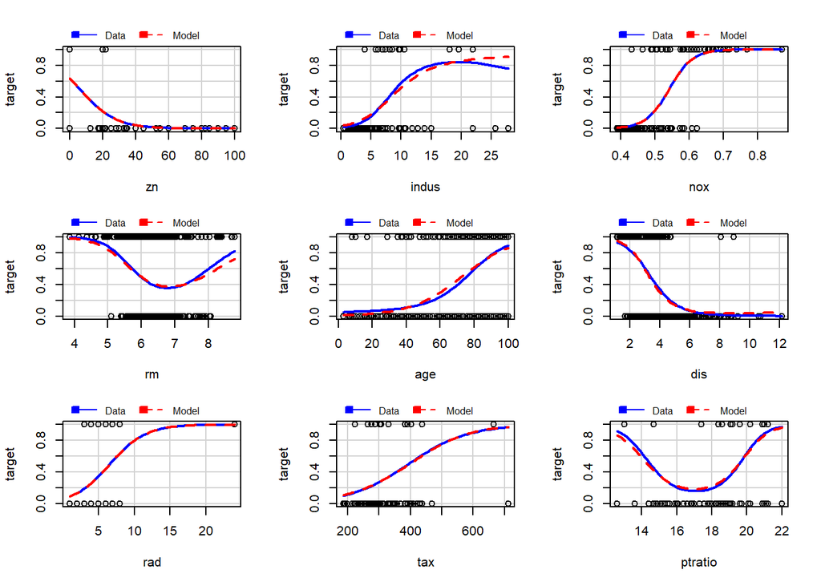

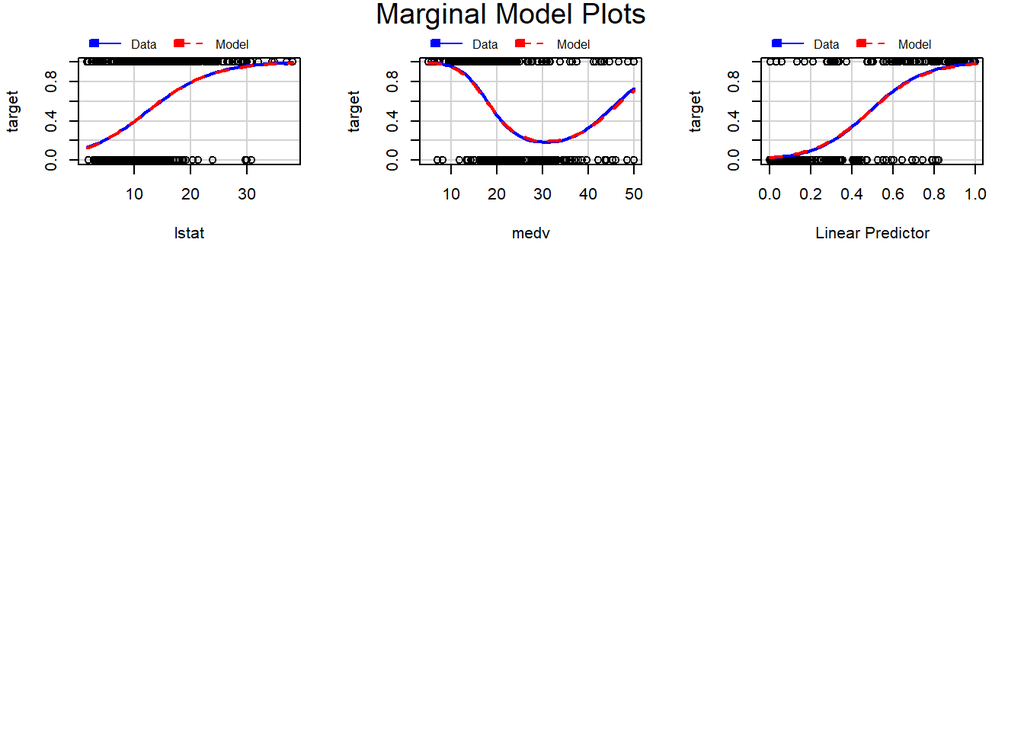

Two which stand out are rad (index of accessibility to radial highways) and tax (full-value property-tax rate per $10,000) which we can transform and then compare the use of the transformed variable and the original in our models.

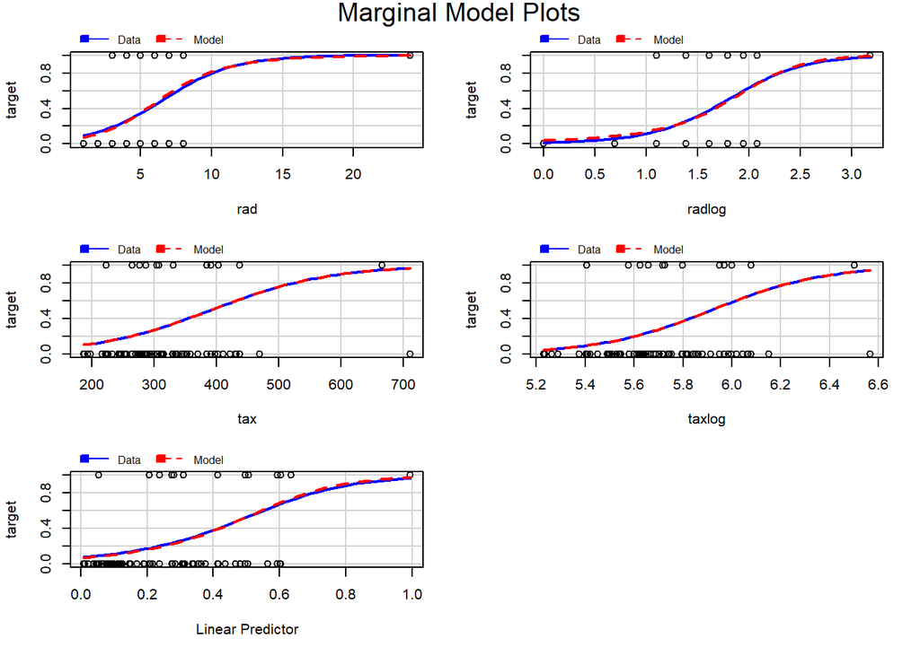

It looks as though our fit has improved. We will determine if this improves the overall model in the next section.